[figure not shown]

Machine Learning 1

**Prof. M.Wilamowski**

# 2008 Democratic Party Presidential Primaries Analysis and Classification Case study

Huseyin Can Minareci & Noam Shmuel

June, 2020

### Introduction

In 2008 the Democratic Party chose its nominee for President of the United States for the presidential election which took place later on that year. The two nominees, Senator Hillary Clinton and Senator Barack Obama, had a close race during the contest. In this report we aim to find the best classification model to predict who will come out as a winner (dependent vatiable) in each county (observation).

### Data preparation

An overview of original initial `primaries` dataset:

| fips | county_name | state_postal | region | election_date | racetype | tvotes | clinton | obama | edwards | margin | winner | POP05_SQMI | popUnder30_00 | pop65up_00 | presVote04 | kerry04 | Bush04 | pres04margin | pres04winner | pop06 | pop00 | hisp06 | white06 | black06 | indian06 | asian06 | hawaii06 | mixed06 | pct_less_30k | … |
| --- | --- | --- | --- | --- | --- | --- | --- | --- | --- | --- | --- | --- | --- | --- | --- | --- | --- | --- | --- | --- | --- | --- | --- | --- | --- | --- | --- | --- | --- | --- |
| 1001 | Autauga | AL | S | 2/5/08 | Primary | 4118 | 1760 | 2268 | 57 | 0.12 | obama | 78.9 | 30.3 | 10.2 | 20081 | 0.24 | 0.76 | 0.52 | bush | 49730 | 43911 | 827 | 39368 | 8559 | 203 | 271 | 12 | 490 | 0.34 | … |
| 1003 | Baldwin | AL | S | 2/5/08 | Primary | 12085 | 6259 | 5450 | 227 | -0.07 | clinton | 97 | 27.2 | 15.5 | 69320 | 0.23 | 0.76 | 0.54 | bush | 169162 | 141423 | 4176 | 145687 | 16301 | 770 | 679 | 42 | 1507 | 0.36 | … |
| 1005 | Barbour | AL | S | 2/5/08 | Primary | 3823 | 1322 | 2393 | 60 | 0.28 | obama | 32.3 | 31.4 | 13.3 | 10777 | 0.45 | 0.55 | 0.1 | bush | 28171 | 29044 | 953 | 13793 | 13035 | 115 | 84 | 6 | 185 | 0.57 | … |
| 1007 | Bibb | AL | S | 2/5/08 | Primary | 1751 | 922 | 755 | 44 | -0.1 | clinton | 33.4 | 32.8 | 11.6 | 7600 | 0.27 | 0.72 | 0.45 | bush | 21482 | 19939 | 304 | 16266 | 4705 | 63 | 25 | 2 | 117 | 0.47 | … |
| 1009 | Blount | AL | S | 2/5/08 | Primary | 3471 | 2735 | 617 | 75 | -0.61 | clinton | 80.7 | 30.2 | 12.9 | 21504 | 0.18 | 0.81 | 0.63 | bush | 56436 | 51229 | 3752 | 51031 | 872 | 238 | 125 | 7 | 411 | 0.41 | … |
| … | NA | NA | NA | NA | NA | … | … | … | … | … | NA | … | … | … | … | … | … | … | NA | … | … | … | … | … | … | … | … | … | … | … |
| 56037 | Sweetwater | WY | W | 3/8/08 | Caucus | 596 | 342 | 254 | 0 | -0.15 | clinton | 3.6 | 29.7 | 8 | 16272 | 0.32 | 0.65 | 0.33 | bush | 38763 | 37504 | 4171 | 32976 | 347 | 353 | 353 | 29 | 534 | 0.3 | … |
| 56039 | Teton | WY | W | 3/8/08 | Caucus | 1150 | 231 | 919 | 0 | 0.6 | obama | 4.5 | 38.6 | 6.9 | 11359 | 0.53 | 0.45 | -0.07 | kerry | 19288 | 18359 | 2253 | 16620 | 39 | 87 | 135 | 5 | 149 | 0.23 | … |
| 56041 | Uinta | WY | W | 3/8/08 | Caucus | 168 | 45 | 123 | 0 | 0.46 | obama | 9.6 | 28.5 | 7 | 8081 | 0.22 | 0.75 | 0.53 | bush | 20213 | 19710 | 1318 | 18351 | 20 | 176 | 65 | 11 | 272 | 0.33 | … |
| 56043 | Washakie | WY | W | 3/8/08 | Caucus | 98 | 40 | 58 | 0 | 0.18 | obama | 3.6 | 23.6 | 15.9 | 4114 | 0.21 | 0.78 | 0.57 | bush | 7819 | 8265 | 1029 | 6577 | 8 | 62 | 53 | 0 | 90 | 0.44 | … |
| 56045 | Weston | WY | W | 3/8/08 | Caucus | 68 | 40 | 28 | 0 | -0.18 | clinton | 2.8 | 24.7 | 15.6 | 3392 | 0.17 | 0.81 | 0.64 | bush | 6762 | 6643 | 175 | 6395 | 9 | 93 | 15 | 1 | 74 | 0.46 | … |

The data is comprised of 2450 observations (counties) and 50 variabels, where the variables are:

```
##  [1] "fips"                "county_name"         "state_postal"
##  [4] "region"              "election_date"       "racetype"
##  [7] "tvotes"              "clinton"             "obama"
## [10] "edwards"             "margin"              "winner"
## [13] "POP05_SQMI"          "popUnder30_00"       "pop65up_00"
## [16] "presVote04"          "kerry04"             "Bush04"
## [19] "pres04margin"        "pres04winner"        "pop06"
## [22] "pop00"               "hisp06"              "white06"
## [25] "black06"             "indian06"            "asian06"
## [28] "hawaii06"            "mixed06"             "pct_less_30k"
## [31] "pct_more_100k"       "pct_hs_grad"         "pct_labor_force"
## [34] "pct_homeowner"       "unempFeb07"          "unempFeb08"
## [37] "unempChg"            "pctUnins00"          "subForPctHomes"
## [40] "poverty05"           "median_hhi05"        "Catholic"
## [43] "So.Bapt.Conv"        "Un.Methodist"        "E.L.C.A."
## [46] "Construction"        "Manufacturing"       "FinancialActivities"
## [49] "GoodsProducing"      "ServiceProviding"
```

Moreover, there are a few variables which are presented as nominal.  
Variables such as: `white06`, `black06`, `indian06`, `asian06`, `hawaii06`, `mixed06` will be normilized against the population in 2006 (`pop06`) in order to represent the ratio of these ethnicity groups in the observed county.  
In addition, instead of showing both the population in the years 2006 and in 2000, a precent change will be more appropriate:

```r
raw.data <-
(
  raw.data %>%
    mutate(pct_white06 =  white06/pop06) %>%
    mutate(pct_black06 =  black06/pop06) %>%
    mutate(pct_indian06 =  indian06/pop06) %>%
    mutate(pct_asian06 =  asian06/pop06) %>%
    mutate(pct_hawaii06 =  hawaii06/pop06) %>%
    mutate(pct_mixed06 =  mixed06/pop06) %>%
    mutate(pct_change_06_00 =  ((pop06/pop00 -1)*100) )
)
```

After the creating the variables above and rearranging them, the dataset looks like:

| winner | POP05_SQMI | tvotes | popUnder30_00 | pop65up_00 | presVote04 | kerry04 | Bush04 | pres04margin | pres04winner | pop06 | pct_change_06_00 | pct_white06 | pct_black06 | pct_indian06 | pct_asian06 | pct_hawaii06 | pct_mixed06 | pct_less_30k | pct_more_100k | pct_hs_grad | pct_labor_force | pct_homeowner | unempFeb07 | unempFeb08 | unempChg | poverty05 | median_hhi05 | Catholic | So.Bapt.Conv | … |
| --- | --- | --- | --- | --- | --- | --- | --- | --- | --- | --- | --- | --- | --- | --- | --- | --- | --- | --- | --- | --- | --- | --- | --- | --- | --- | --- | --- | --- | --- | --- |
| obama | 78.9 | 4118 | 30.3 | 10.2 | 20081 | 0.24 | 0.76 | 0.52 | bush | 49730 | 13.25 | 0.79 | 0.17 | 0 | 0.01 | 0 | 0.01 | 0.34 | 0.08 | 0.79 | 0.65 | 0.81 | 3 | 3.6 | 0.6 | 10.4 | 45019 | 0.03 | 0.34 | … |
| clinton | 97 | 12085 | 27.2 | 15.5 | 69320 | 0.23 | 0.76 | 0.54 | bush | 169162 | 19.61 | 0.86 | 0.1 | 0 | 0 | 0 | 0.01 | 0.36 | 0.09 | 0.82 | 0.6 | 0.8 | 3.1 | 3.4 | 0.3 | 11.4 | 42804 | 0.07 | 0.2 | … |
| obama | 32.3 | 3823 | 31.4 | 13.3 | 10777 | 0.45 | 0.55 | 0.1 | bush | 28171 | -3.01 | 0.49 | 0.46 | 0 | 0 | 0 | 0.01 | 0.57 | 0.05 | 0.65 | 0.48 | 0.73 | 5 | 7.1 | 2.1 | 22.4 | 29534 | 0.01 | 0.26 | … |
| clinton | 33.4 | 1751 | 32.8 | 11.6 | 7600 | 0.27 | 0.72 | 0.45 | bush | 21482 | 7.74 | 0.76 | 0.22 | 0 | 0 | 0 | 0.01 | 0.47 | 0.04 | 0.63 | 0.53 | 0.8 | 3.7 | 4.2 | 0.5 | 16.6 | 34212 | 0 | 0.39 | … |
| clinton | 80.7 | 3471 | 30.2 | 12.9 | 21504 | 0.18 | 0.81 | 0.63 | bush | 56436 | 10.16 | 0.9 | 0.02 | 0 | 0 | 0 | 0.01 | 0.41 | 0.05 | 0.7 | 0.61 | 0.83 | 3.1 | 3.3 | 0.2 | 11.4 | 40588 | 0.01 | 0.36 | … |
| NA | … | … | … | … | … | … | … | … | NA | … | … | … | … | … | … | … | … | … | … | … | … | … | … | … | … | … | … | … | … | … |
| clinton | 3.6 | 596 | 29.7 | 8 | 16272 | 0.32 | 0.65 | 0.33 | bush | 38763 | 3.36 | 0.85 | 0.01 | 0.01 | 0.01 | 0 | 0.01 | 0.3 | 0.08 | 0.87 | 0.71 | 0.75 | 2.4 | 2.6 | 0.2 | 7.6 | 57211 | 0.27 | 0.04 | … |
| obama | 4.5 | 1150 | 38.6 | 6.9 | 11359 | 0.53 | 0.45 | -0.07 | kerry | 19288 | 5.06 | 0.86 | 0 | 0 | 0.01 | 0 | 0.01 | 0.23 | 0.19 | 0.95 | 0.79 | 0.55 | 2.2 | 2.3 | 0.1 | 6.1 | 60314 | 0.1 | 0.01 | … |
| obama | 9.6 | 168 | 28.5 | 7 | 8081 | 0.22 | 0.75 | 0.53 | bush | 20213 | 2.55 | 0.91 | 0 | 0.01 | 0 | 0 | 0.01 | 0.33 | 0.05 | 0.85 | 0.71 | 0.75 | 3 | 3.5 | 0.5 | 10.5 | 48557 | 0.09 | 0.04 | … |
| obama | 3.6 | 98 | 23.6 | 15.9 | 4114 | 0.21 | 0.78 | 0.57 | bush | 7819 | -5.4 | 0.84 | 0 | 0.01 | 0.01 | 0 | 0.01 | 0.44 | 0.07 | 0.86 | 0.67 | 0.73 | 4.4 | 4.5 | 0.1 | 12.6 | 41584 | 0.14 | 0.06 | … |
| clinton | 2.8 | 68 | 24.7 | 15.6 | 3392 | 0.17 | 0.81 | 0.64 | bush | 6762 | 1.79 | 0.95 | 0 | 0.01 | 0 | 0 | 0.01 | 0.46 | 0.05 | 0.85 | 0.6 | 0.78 | 3.5 | 3.6 | 0.1 | 9.4 | 40736 | 0.12 | 0.01 | … |

Now that the dateset it arranged in proper way, the next step would be to get to know the data with explanatory data analysis:

### Explanatory Data Analysis and Summary Statistics

Next step would be to observing key independent varibles and their distribution. It’s crystal clear that the total votes, `tvotes`, is skewed.

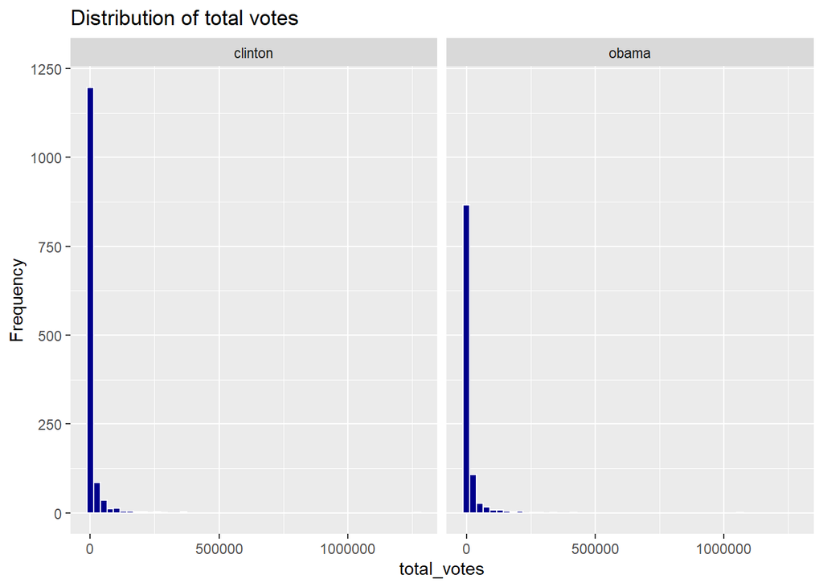

Therefor, we will perform a log transformation on this vatiable to make it normally distributed:

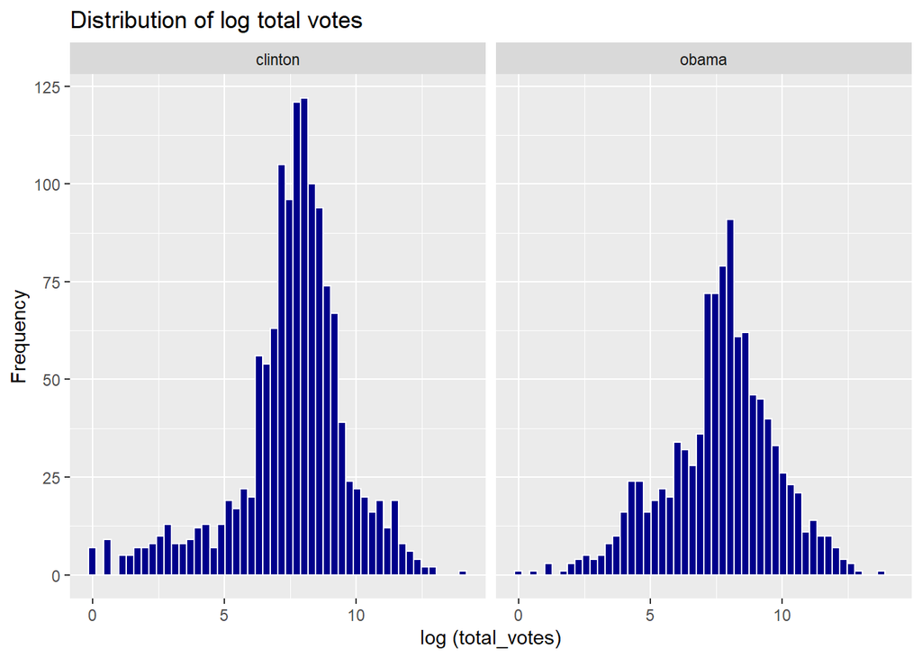

Next step would be a summary statistics overview of the independent variables:

|  | vars | n | mean | sd | median | trimmed | mad | min | max | range | skew | kurtosis | se |
| --- | --- | --- | --- | --- | --- | --- | --- | --- | --- | --- | --- | --- | --- |
| POP05_SQMI | 1 | 2449 | 282.70 | 1744.86 | 44.60 | 76.71 | 47.44 | 0.10 | 57173.00 | 57172.90 | 21.71 | 589.69 | 35.26 |
| tvotes | 2 | 2450 | 11792.21 | 45099.70 | 2469.50 | 4002.93 | 3111.98 | 1.00 | 1271094.00 | 1271093.00 | 15.90 | 374.25 | 911.15 |
| popUnder30_00 | 3 | 2449 | 28.95 | 4.98 | 28.60 | 28.60 | 3.71 | 11.90 | 60.00 | 48.10 | 1.28 | 4.49 | 0.10 |
| pop65up_00 | 4 | 2449 | 14.42 | 4.00 | 14.10 | 14.25 | 3.56 | 1.80 | 34.70 | 32.90 | 0.55 | 1.12 | 0.08 |
| presVote04 | 5 | 2449 | 45242.98 | 125747.06 | 11698.00 | 19559.93 | 11547.97 | 80.00 | 3023280.00 | 3023200.00 | 10.04 | 170.33 | 2540.99 |
| kerry04 | 6 | 2449 | 0.39 | 0.13 | 0.39 | 0.39 | 0.13 | 0.07 | 0.89 | 0.82 | 0.34 | 0.24 | 0.00 |
| Bush04 | 7 | 2449 | 0.60 | 0.13 | 0.60 | 0.60 | 0.13 | 0.09 | 0.92 | 0.83 | -0.33 | 0.17 | 0.00 |
| pres04margin | 8 | 2449 | 0.20 | 0.25 | 0.21 | 0.21 | 0.25 | -0.80 | 0.85 | 1.65 | -0.34 | 0.20 | 0.01 |
| pop06 | 9 | 2449 | 113964.18 | 359707.48 | 28785.00 | 47072.90 | 28818.78 | 60.00 | 9948081.00 | 9948021.00 | 12.77 | 266.83 | 7268.67 |
| pct_change_06_00 | 10 | 2449 | 3.95 | 9.10 | 2.48 | 2.95 | 6.16 | -76.85 | 64.24 | 141.09 | 1.24 | 8.10 | 0.18 |
| pct_white06 | 11 | 2449 | 0.76 | 0.20 | 0.81 | 0.79 | 0.19 | 0.02 | 0.99 | 0.97 | -1.11 | 0.85 | 0.00 |
| pct_black06 | 12 | 2449 | 0.10 | 0.15 | 0.03 | 0.07 | 0.04 | 0.00 | 0.85 | 0.85 | 2.00 | 3.81 | 0.00 |
| pct_indian06 | 13 | 2449 | 0.01 | 0.04 | 0.00 | 0.00 | 0.00 | 0.00 | 0.79 | 0.79 | 11.20 | 179.94 | 0.00 |
| pct_asian06 | 14 | 2449 | 0.01 | 0.02 | 0.00 | 0.01 | 0.00 | 0.00 | 0.32 | 0.32 | 6.27 | 58.25 | 0.00 |
| pct_hawaii06 | 15 | 2449 | 0.00 | 0.00 | 0.00 | 0.00 | 0.00 | 0.00 | 0.01 | 0.01 | 6.25 | 54.82 | 0.00 |
| pct_mixed06 | 16 | 2449 | 0.01 | 0.01 | 0.01 | 0.01 | 0.00 | 0.00 | 0.11 | 0.11 | 4.14 | 26.95 | 0.00 |
| pct_less_30k | 17 | 2448 | 0.43 | 0.11 | 0.44 | 0.43 | 0.10 | 0.08 | 0.74 | 0.65 | -0.37 | -0.02 | 0.00 |
| pct_more_100k | 18 | 2448 | 0.07 | 0.05 | 0.05 | 0.06 | 0.02 | 0.00 | 0.38 | 0.38 | 2.63 | 8.71 | 0.00 |
| pct_hs_grad | 19 | 2448 | 0.77 | 0.09 | 0.78 | 0.77 | 0.09 | 0.35 | 0.97 | 0.62 | -0.55 | 0.22 | 0.00 |
| pct_labor_force | 20 | 2448 | 0.60 | 0.07 | 0.61 | 0.61 | 0.07 | 0.32 | 0.86 | 0.54 | -0.28 | 0.24 | 0.00 |
| pct_homeowner | 21 | 2448 | 0.74 | 0.08 | 0.75 | 0.75 | 0.06 | 0.20 | 0.90 | 0.70 | -1.56 | 4.82 | 0.00 |
| unempFeb07 | 22 | 2441 | 5.57 | 2.13 | 5.10 | 5.33 | 1.78 | 1.70 | 21.90 | 20.20 | 1.55 | 4.47 | 0.04 |
| unempFeb08 | 23 | 2441 | 5.70 | 2.19 | 5.30 | 5.46 | 1.93 | 1.60 | 23.20 | 21.60 | 1.48 | 4.49 | 0.04 |
| unempChg | 24 | 2441 | 0.13 | 0.90 | 0.10 | 0.11 | 0.89 | -3.80 | 9.30 | 13.10 | 0.69 | 6.50 | 0.02 |
| poverty05 | 25 | 2450 | 15.70 | 6.63 | 14.80 | 15.16 | 6.23 | 2.50 | 46.40 | 43.90 | 0.93 | 1.41 | 0.13 |
| median_hhi05 | 26 | 2450 | 39551.62 | 10571.43 | 37440.00 | 38290.28 | 8347.04 | 17843.00 | 98245.00 | 80402.00 | 1.42 | 3.03 | 213.58 |
| Catholic | 27 | 2447 | 0.14 | 0.15 | 0.09 | 0.11 | 0.11 | 0.00 | 0.95 | 0.95 | 1.71 | 3.39 | 0.00 |
| So.Bapt.Conv | 28 | 2447 | 0.16 | 0.16 | 0.12 | 0.14 | 0.17 | 0.00 | 0.96 | 0.96 | 0.88 | 0.21 | 0.00 |
| Un.Methodist | 29 | 2447 | 0.06 | 0.04 | 0.05 | 0.06 | 0.04 | 0.00 | 0.34 | 0.34 | 1.38 | 3.41 | 0.00 |
| Construction | 30 | 2447 | Inf | NaN | 6.19 | 6.55 | 3.54 | 0.00 | Inf | Inf | NaN | NaN | NaN |
| Manufacturing | 31 | 2447 | Inf | NaN | 13.72 | 14.70 | 12.16 | 0.00 | Inf | Inf | NaN | NaN | NaN |
| FinancialActivities | 32 | 2449 | Inf | NaN | 4.65 | 4.82 | 1.69 | 0.00 | Inf | Inf | NaN | NaN | NaN |
| GoodsProducing | 33 | 2445 | Inf | NaN | 28.90 | 29.69 | 13.20 | 0.00 | Inf | Inf | NaN | NaN | NaN |
| ServiceProviding | 34 | 2448 | Inf | NaN | 71.01 | 70.15 | 13.22 | 0.00 | Inf | Inf | NaN | NaN | NaN |
| log_tvotes | 35 | 2450 | 7.58 | 2.13 | 7.81 | 7.72 | 1.56 | 0.00 | 14.06 | 14.06 | -0.71 | 1.20 | 0.04 |

It accures that the variables `Construction`, `Manufacturing`, `FinancialActivities`, `GoodsProducing`, `ServiceProviding` have some Infinite values. Let examine how many Infinite values are there under `Construction`, but sorting the values in descending order:

| Construction |
| --- |
| Inf |
| Inf |
| Inf |
| Inf |
| 47.98992 |
| 39.46144 |
| 36.90827 |
| 35.70033 |

The next step would be handaling these infinite values. There is no absolute best partice with how to deal with Inf value, we could either remove these records, or replace them with other values, such as `0`. However we would use winsorization and replce them with the 99th quantile.

```r
pro_vec <- c("Construction", "Manufacturing", "FinancialActivities",
             "GoodsProducing", "ServiceProviding"  )
for (colname in pro_vec) {
  qua99 <- quantile(raw.data[[colname]],probs = 0.99,na.rm = T)
  vecc <- raw.data[[colname]]
  raw.data[[colname]] <- DescTools::Winsorize(vecc,maxval = qua99,na.rm = T)
}
```

The complete summary statistics table:

|  | vars | n | mean | sd | median | trimmed | mad | min | max | range | skew | kurtosis | se |
| --- | --- | --- | --- | --- | --- | --- | --- | --- | --- | --- | --- | --- | --- |
| POP05_SQMI | 1 | 2449 | 282.70 | 1744.86 | 44.60 | 76.71 | 47.44 | 0.10 | 57173.00 | 57172.90 | 21.71 | 589.69 | 35.26 |
| tvotes | 2 | 2450 | 11792.21 | 45099.70 | 2469.50 | 4002.93 | 3111.98 | 1.00 | 1271094.00 | 1271093.00 | 15.90 | 374.25 | 911.15 |
| popUnder30_00 | 3 | 2449 | 28.95 | 4.98 | 28.60 | 28.60 | 3.71 | 11.90 | 60.00 | 48.10 | 1.28 | 4.49 | 0.10 |
| pop65up_00 | 4 | 2449 | 14.42 | 4.00 | 14.10 | 14.25 | 3.56 | 1.80 | 34.70 | 32.90 | 0.55 | 1.12 | 0.08 |
| presVote04 | 5 | 2449 | 45242.98 | 125747.06 | 11698.00 | 19559.93 | 11547.97 | 80.00 | 3023280.00 | 3023200.00 | 10.04 | 170.33 | 2540.99 |
| kerry04 | 6 | 2449 | 0.39 | 0.13 | 0.39 | 0.39 | 0.13 | 0.07 | 0.89 | 0.82 | 0.34 | 0.24 | 0.00 |
| Bush04 | 7 | 2449 | 0.60 | 0.13 | 0.60 | 0.60 | 0.13 | 0.09 | 0.92 | 0.83 | -0.33 | 0.17 | 0.00 |
| pres04margin | 8 | 2449 | 0.20 | 0.25 | 0.21 | 0.21 | 0.25 | -0.80 | 0.85 | 1.65 | -0.34 | 0.20 | 0.01 |
| pop06 | 9 | 2449 | 113964.18 | 359707.48 | 28785.00 | 47072.90 | 28818.78 | 60.00 | 9948081.00 | 9948021.00 | 12.77 | 266.83 | 7268.67 |
| pct_change_06_00 | 10 | 2449 | 3.95 | 9.10 | 2.48 | 2.95 | 6.16 | -76.85 | 64.24 | 141.09 | 1.24 | 8.10 | 0.18 |
| pct_white06 | 11 | 2449 | 0.76 | 0.20 | 0.81 | 0.79 | 0.19 | 0.02 | 0.99 | 0.97 | -1.11 | 0.85 | 0.00 |
| pct_black06 | 12 | 2449 | 0.10 | 0.15 | 0.03 | 0.07 | 0.04 | 0.00 | 0.85 | 0.85 | 2.00 | 3.81 | 0.00 |
| pct_indian06 | 13 | 2449 | 0.01 | 0.04 | 0.00 | 0.00 | 0.00 | 0.00 | 0.79 | 0.79 | 11.20 | 179.94 | 0.00 |
| pct_asian06 | 14 | 2449 | 0.01 | 0.02 | 0.00 | 0.01 | 0.00 | 0.00 | 0.32 | 0.32 | 6.27 | 58.25 | 0.00 |
| pct_hawaii06 | 15 | 2449 | 0.00 | 0.00 | 0.00 | 0.00 | 0.00 | 0.00 | 0.01 | 0.01 | 6.25 | 54.82 | 0.00 |
| pct_mixed06 | 16 | 2449 | 0.01 | 0.01 | 0.01 | 0.01 | 0.00 | 0.00 | 0.11 | 0.11 | 4.14 | 26.95 | 0.00 |
| pct_less_30k | 17 | 2448 | 0.43 | 0.11 | 0.44 | 0.43 | 0.10 | 0.08 | 0.74 | 0.65 | -0.37 | -0.02 | 0.00 |
| pct_more_100k | 18 | 2448 | 0.07 | 0.05 | 0.05 | 0.06 | 0.02 | 0.00 | 0.38 | 0.38 | 2.63 | 8.71 | 0.00 |
| pct_hs_grad | 19 | 2448 | 0.77 | 0.09 | 0.78 | 0.77 | 0.09 | 0.35 | 0.97 | 0.62 | -0.55 | 0.22 | 0.00 |
| pct_labor_force | 20 | 2448 | 0.60 | 0.07 | 0.61 | 0.61 | 0.07 | 0.32 | 0.86 | 0.54 | -0.28 | 0.24 | 0.00 |
| pct_homeowner | 21 | 2448 | 0.74 | 0.08 | 0.75 | 0.75 | 0.06 | 0.20 | 0.90 | 0.70 | -1.56 | 4.82 | 0.00 |
| unempFeb07 | 22 | 2441 | 5.57 | 2.13 | 5.10 | 5.33 | 1.78 | 1.70 | 21.90 | 20.20 | 1.55 | 4.47 | 0.04 |
| unempFeb08 | 23 | 2441 | 5.70 | 2.19 | 5.30 | 5.46 | 1.93 | 1.60 | 23.20 | 21.60 | 1.48 | 4.49 | 0.04 |
| unempChg | 24 | 2441 | 0.13 | 0.90 | 0.10 | 0.11 | 0.89 | -3.80 | 9.30 | 13.10 | 0.69 | 6.50 | 0.02 |
| poverty05 | 25 | 2450 | 15.70 | 6.63 | 14.80 | 15.16 | 6.23 | 2.50 | 46.40 | 43.90 | 0.93 | 1.41 | 0.13 |
| median_hhi05 | 26 | 2450 | 39551.62 | 10571.43 | 37440.00 | 38290.28 | 8347.04 | 17843.00 | 98245.00 | 80402.00 | 1.42 | 3.03 | 213.58 |
| Catholic | 27 | 2447 | 0.14 | 0.15 | 0.09 | 0.11 | 0.11 | 0.00 | 0.95 | 0.95 | 1.71 | 3.39 | 0.00 |
| So.Bapt.Conv | 28 | 2447 | 0.16 | 0.16 | 0.12 | 0.14 | 0.17 | 0.00 | 0.96 | 0.96 | 0.88 | 0.21 | 0.00 |
| Un.Methodist | 29 | 2447 | 0.06 | 0.04 | 0.05 | 0.06 | 0.04 | 0.00 | 0.34 | 0.34 | 1.38 | 3.41 | 0.00 |
| Construction | 30 | 2447 | 6.98 | 4.69 | 6.19 | 6.55 | 3.54 | 0.00 | 25.03 | 25.03 | 1.24 | 2.49 | 0.09 |
| Manufacturing | 31 | 2447 | 15.91 | 12.27 | 13.72 | 14.70 | 12.16 | 0.00 | 52.20 | 52.20 | 0.81 | 0.11 | 0.25 |
| FinancialActivities | 32 | 2449 | 5.07 | 2.18 | 4.65 | 4.82 | 1.69 | 2.06 | 13.78 | 11.72 | 1.38 | 2.70 | 0.04 |
| GoodsProducing | 33 | 2445 | 30.61 | 12.61 | 28.90 | 29.69 | 13.20 | 12.25 | 66.26 | 54.01 | 0.62 | -0.17 | 0.26 |
| ServiceProviding | 34 | 2448 | 69.65 | 12.19 | 71.01 | 70.15 | 13.22 | 45.72 | 92.96 | 47.24 | -0.31 | -0.77 | 0.25 |
| log_tvotes | 35 | 2450 | 7.58 | 2.13 | 7.81 | 7.72 | 1.56 | 0.00 | 14.06 | 14.06 | -0.71 | 1.20 | 0.04 |

The dependent variables are distributed accordingly:

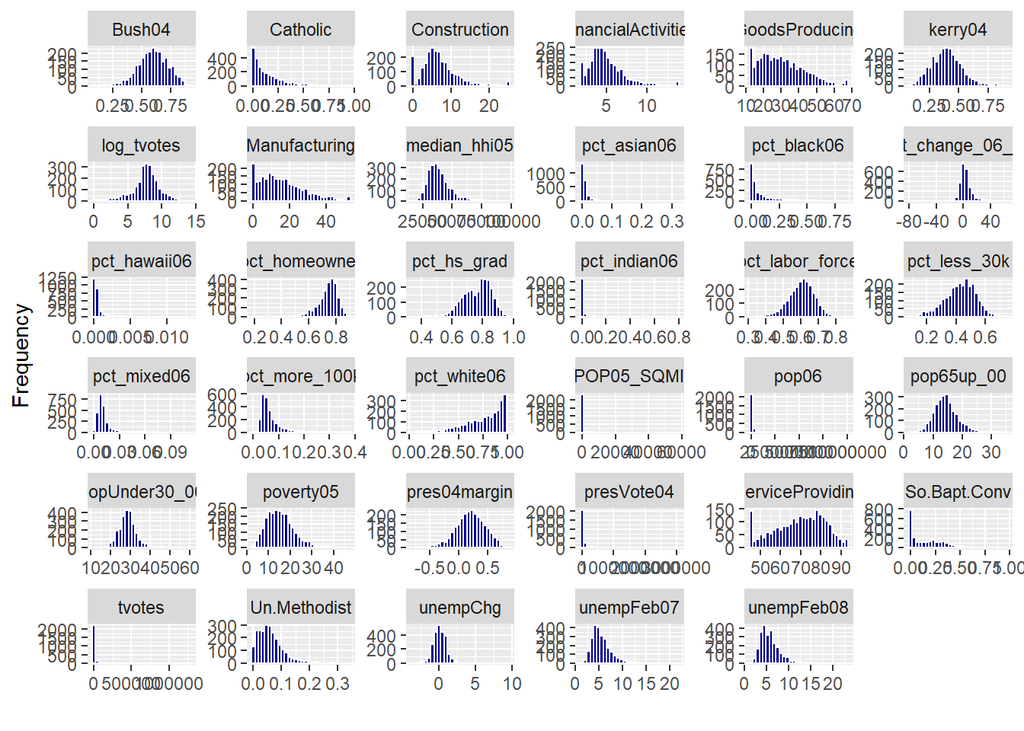

Both the summary statistics table and the distribution plot reveal that variable, `pop06` (total population in the observed country) is extremly skewed to the right. Since we’ve already created a variable which is the percent change in population from 2000 to 2006 (`pct_change_06_00`), in order to avoid multicollinearity between these 2 variables we will remove `pop06` from the dataset. There are some addition skewed variables such as `pct_white06`, `pct_black06`, `pct_indian06`, `pct_asian06`, `pct_hawaii06`and `pct_mixed06` which we may consider removing, howevert these varialbes are rates and naturally these rate variables repersanting minorities are close to zero. With further analysis we shall verifiy if whether they ought to be ommited from the the dataset.

The final step of the explanatory data analysis is the corrlation matrix of the variables.

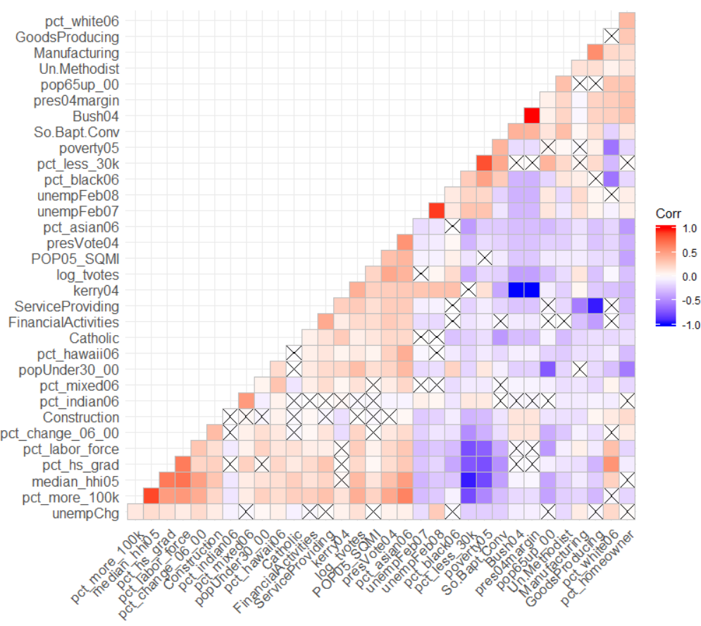

### Missing Values

In the exploratory data analysis we have removed problematic values of `inf+`, we are going to apply similar and yet different aproach on the `NA` values in the independent variables.  
However, First step would be the dependent variable, `winner`, and its distribution between the two candidates:

```r
table(raw.data$winner,  exclude = NULL)
```

```
##
## clinton   obama    <NA>
##    1369    1061      20
```

As shown in the table above, there are 20 missing values of the dependent variable,`winner`, therefore, these 20 observations will be removed from the dataset.

Moving to handling missing values in the independent variables.  
The number of missing values under each variable is showing in the table below:

```r
as.table(colSums(is.na(raw.data)))
```

```
##              winner          POP05_SQMI       popUnder30_00
##                   0                   1                   1
##          pop65up_00          presVote04             kerry04
##                   1                   1                   1
##              Bush04        pres04margin        pres04winner
##                   1                   1                   1
##          log_tvotes    pct_change_06_00         pct_white06
##                   0                   1                   1
##         pct_black06        pct_indian06         pct_asian06
##                   1                   1                   1
##        pct_hawaii06         pct_mixed06        pct_less_30k
##                   1                   1                   2
##       pct_more_100k         pct_hs_grad     pct_labor_force
##                   2                   2                   2
##       pct_homeowner          unempFeb07          unempFeb08
##                   2                   9                   9
##            unempChg           poverty05        median_hhi05
##                   9                   0                   0
##            Catholic        So.Bapt.Conv        Un.Methodist
##                   3                   3                   3
##        Construction       Manufacturing FinancialActivities
##                   2                   2                   1
##      GoodsProducing    ServiceProviding
##                   5                   1
```

There are 72 `NA`’s in total in the dataset, which consist at the most 2.963% of records.

As seen in the numeric variables distribution plot, most of the variables are distributed in normal mannor, therefore we can conclude that replacing missing values with the median of each variable would be good parctice. Replacing `NA`’s with median is presented in the function below

```r
for (col_name in raw.data %>%  keep(is.numeric) %>%   colnames()  ) {
   col_median <- median(raw.data[[col_name]], na.rm = TRUE)
   raw.data[[col_name]][is.na(raw.data[[col_name]])] <- col_median
}
rm(col_median,col_name)
```

Verifying that the missing values were indeed successfuly removed

```r
sum(colSums(is.na(raw.data %>%  keep(is.numeric))))
```

```
## [1] 0
```

Setting “Obama” to be success (as we know he won the elections):

```r
raw.data <- raw.data %>%
  mutate(winner = as.factor(ifelse(raw.data$winner=="obama",1,0)))


raw.data$winner <- factor(raw.data$winner,
                              levels = c(0, 1),
                              labels = c("clinton", "obama"))
```

Now that we have dealt with abnormal values, such as infinite, and missing values, the dataset is prepared for the main part of the analysis.

### Data Partition

We start with partitioning the dataset in ratio 80-20 towards the train dataset, and making sure that the 80-20 ratio will be kept within the dependent varible in the train and test datasets.

```r
set.seed(123321)
training_index <- createDataPartition(primaries$winner, p = 0.8, list = FALSE)
primaries_train <- primaries[training_index,]
primaries_test <- primaries[-training_index,]
```

Verifying that the dependent variable is distributed in equal rates between the train and test datasets:

```r
prop.table(table(primaries_train$winner))
```

```
##
##  clinton    obama
## 0.563786 0.436214
```

```r
prop.table(table(primaries_test$winner))
```

```
##
##   clinton     obama
## 0.5628866 0.4371134
```

The partition of the dataset went well, the dependent variable is distributed evenly between the the train and test datasets.

### Logistic Model

We start the classification part with Logistic Modeling.  
In the first Model of the Logit we use every single one of the variables we have in the dataset as predictors:

```r
model1 <- glm(winner ~.,data=primaries_train, family=binomial(link = "logit"))
summary(model1)
```

```
##
## Call:
## glm(formula = winner ~ ., family = binomial(link = "logit"),
##     data = primaries_train)
##
## Deviance Residuals:
##     Min       1Q   Median       3Q      Max
## -3.5379  -0.6108  -0.1129   0.6155   2.7080
##
## Coefficients: (1 not defined because of singularities)
##                                 Estimate           Std. Error z value
## (Intercept)                35.1778186701        15.1637907700   2.320
## POP05_SQMI                 -0.0000746542         0.0000549567  -1.358
## popUnder30_00               0.0530659303         0.0284249648   1.867
## pop65up_00                  0.0489881836         0.0405228340   1.209
## presVote04                 -0.0000007893         0.0000007382  -1.069
## kerry04              42977977.4882350266 133282386.0085618198   0.322
## Bush04              -42978086.2200126350 133282385.2838792801  -0.322
## pres04margin         42978030.4512840956 133282385.6702385396   0.322
## pres04winnerkerry          -0.2982604339         0.2420770393  -1.232
## log_tvotes                 -0.4762214546         0.0485155547  -9.816
## pct_change_06_00            0.0208210365         0.0096027612   2.168
## pct_white06                 0.0857670377         0.9867981166   0.087
## pct_black06                18.5801993398         1.2429284249  14.949
## pct_indian06                7.3279473565         2.2298135675   3.286
## pct_asian06                 4.8600862189         4.8194328454   1.008
## pct_hawaii06              110.7438654713        81.8160713785   1.354
## pct_mixed06               -66.5711544811        15.9107574422  -4.184
## pct_less_30k               -0.3162509401         2.7873154297  -0.113
## pct_more_100k              -5.9092437835         3.8634344559  -1.530
## pct_hs_grad                10.3393656477         1.8523399990   5.582
## pct_labor_force            12.0483337673         2.0631985453   5.840
## pct_homeowner              -2.3809230451         1.7190263395  -1.385
## unempFeb07                 -0.0118918266         0.0937138220  -0.127
## unempFeb08                 -0.0377709258         0.0929660660  -0.406
## unempChg                              NA                   NA      NA
## poverty05                  -0.0473434272         0.0377070865  -1.256
## median_hhi05                0.0000110567         0.0000299122   0.370
## Catholic                   -1.8911720452         0.6003631030  -3.150
## So.Bapt.Conv               -5.1625154970         0.7906532556  -6.529
```

[output cut: 37 more lines]

```
## Construction                    0.003932 **
## Manufacturing                   0.263601
## FinancialActivities             0.598987
## GoodsProducing                  0.000955 ***
## ServiceProviding                0.002963 **
## ---
## Signif. codes:  0 '***' 0.001 '**' 0.01 '*' 0.05 '.' 0.1 ' ' 1
##
## (Dispersion parameter for binomial family taken to be 1)
##
##     Null deviance: 2663.2  on 1943  degrees of freedom
## Residual deviance: 1519.9  on 1910  degrees of freedom
## AIC: 1587.9
##
## Number of Fisher Scoring iterations: 6
```

Just like suspected in the explanatory data analysis part, it seems like there are many varibles are collinear with one another. The output of the model reveals the variables such as `kerry04`, `Bush04` and `pres04margin` are insignificant most likely for the reason that they are correlated. Therefore we shall remove both `kerry04`and `Bush04`. The same with `unempFeb07`, `unempFeb08` and `unempChg`, we shall keep only the latter one.

```r
model2 <- glm(winner ~., family=binomial(link = "logit"),
              data=primaries_train %>%
                dplyr::select(c(-kerry04,-Bush04,-unempFeb08,-unempFeb07))
              )

summary(model2)
```

```
##
## Call:
## glm(formula = winner ~ ., family = binomial(link = "logit"),
##     data = primaries_train %>% dplyr::select(c(-kerry04, -Bush04,
##         -unempFeb08, -unempFeb07)))
##
## Deviance Residuals:
##     Min       1Q   Median       3Q      Max
## -3.4150  -0.6219  -0.1092   0.6370   2.7025
##
## Coefficients:
##                           Estimate     Std. Error z value
## (Intercept)         -17.8145883448   4.3980480755  -4.051
## POP05_SQMI           -0.0000899778   0.0000574994  -1.565
## popUnder30_00         0.0367595380   0.0270880524   1.357
## pop65up_00            0.0254675301   0.0392904759   0.648
## presVote04           -0.0000008628   0.0000007392  -1.167
## pres04margin         -1.5060925910   0.4972281876  -3.029
## pres04winnerkerry    -0.2876528551   0.2356917395  -1.220
## log_tvotes           -0.4985339389   0.0481984289 -10.343
## pct_change_06_00      0.0222844242   0.0095603655   2.331
## pct_white06           0.7546189528   0.9492587103   0.795
## pct_black06          19.0845013105   1.2382370243  15.413
## pct_indian06          7.7625262732   2.1608122504   3.592
## pct_asian06           5.6776272902   4.7227941149   1.202
## pct_hawaii06        148.0143048848  78.1826108717   1.893
## pct_mixed06         -68.8920923663  15.2589633525  -4.515
## pct_less_30k          0.9571206086   2.7559325612   0.347
## pct_more_100k        -5.6423145438   3.8418798924  -1.469
## pct_hs_grad          10.9168380100   1.8295485443   5.967
## pct_labor_force      11.5486063447   2.0099228815   5.746
## pct_homeowner        -3.9818510332   1.6363907537  -2.433
## unempChg              0.0238035866   0.0904203814   0.263
## poverty05            -0.0589204120   0.0373976790  -1.576
## median_hhi05          0.0000149897   0.0000294932   0.508
## Catholic             -1.7735641802   0.5950654375  -2.980
## So.Bapt.Conv         -5.5987669053   0.7755336745  -7.219
## Un.Methodist         -6.2376660573   1.8626742317  -3.349
## Construction          0.0558807408   0.0174159175   3.209
## Manufacturing        -0.0137499289   0.0089129780  -1.543
```

[output cut: 30 more lines]

```
## Construction                    0.001334 **
## Manufacturing                   0.122907
## FinancialActivities             0.728135
## GoodsProducing                  0.000733 ***
## ServiceProviding                0.003333 **
## ---
## Signif. codes:  0 '***' 0.001 '**' 0.01 '*' 0.05 '.' 0.1 ' ' 1
##
## (Dispersion parameter for binomial family taken to be 1)
##
##     Null deviance: 2663.2  on 1943  degrees of freedom
## Residual deviance: 1534.8  on 1913  degrees of freedom
## AIC: 1596.8
##
## Number of Fisher Scoring iterations: 6
```

```
##  [1] "winner"           "POP05_SQMI"       "pres04margin"
##  [4] "log_tvotes"       "pct_change_06_00" "pct_black06"
##  [7] "pct_indian06"     "pct_mixed06"      "pct_less_30k"
## [10] "pct_hs_grad"      "pct_labor_force"  "pct_homeowner"
## [13] "poverty05"        "Catholic"         "So.Bapt.Conv"
## [16] "Un.Methodist"     "Construction"     "GoodsProducing"
## [19] "ServiceProviding"
```

```r
model3 <- glm(winner ~., family=binomial(link = "logit"),
              data=primaries_train %>%
                dplyr::select(c(-kerry04,-Bush04,-unempFeb08,-unempFeb07,-pres04winner,
                         -pct_hawaii06,-pct_asian06,
                         -FinancialActivities,-Manufacturing,
                         -unempChg,
                         -pop65up_00,
                         -presVote04,
                         -pct_more_100k,
                         -median_hhi05,
                         -pct_white06,
                         -popUnder30_00))
              )

summary(model3)
```

```
##
## Call:
## glm(formula = winner ~ ., family = binomial(link = "logit"),
##     data = primaries_train %>% dplyr::select(c(-kerry04, -Bush04,
##         -unempFeb08, -unempFeb07, -pres04winner, -pct_hawaii06,
##         -pct_asian06, -FinancialActivities, -Manufacturing, -unempChg,
##         -pop65up_00, -presVote04, -pct_more_100k, -median_hhi05,
##         -pct_white06, -popUnder30_00)))
##
## Deviance Residuals:
##     Min       1Q   Median       3Q      Max
## -3.4482  -0.6385  -0.1217   0.6298   2.6180
##
## Coefficients:
##                      Estimate   Std. Error z value             Pr(>|z|)
## (Intercept)      -15.28665872   3.31537944  -4.611     0.00000401059916
## POP05_SQMI        -0.00010068   0.00005392  -1.867             0.061862
## pres04margin      -1.12625829   0.37816525  -2.978             0.002899
## log_tvotes        -0.50182589   0.04251853 -11.803 < 0.0000000000000002
## pct_change_06_00   0.02206793   0.00911723   2.420             0.015501
## pct_black06       18.20297615   1.07149618  16.988 < 0.0000000000000002
## pct_indian06       6.80937714   2.01855025   3.373             0.000742
## pct_mixed06      -58.17111609  13.30718106  -4.371     0.00001234479357
## pct_less_30k       2.57565157   1.65931398   1.552             0.120605
## pct_hs_grad       11.41993139   1.60795701   7.102     0.00000000000123
## pct_labor_force   11.14920819   1.66393108   6.701     0.00000000002077
## pct_homeowner     -4.88774281   1.26165163  -3.874             0.000107
## poverty05         -0.07126725   0.02953080  -2.413             0.015808
## Catholic          -2.22383319   0.55790099  -3.986     0.00006717629647
## So.Bapt.Conv      -5.99306527   0.72930482  -8.218 < 0.0000000000000002
## Un.Methodist      -6.19090668   1.71784140  -3.604             0.000313
## Construction       0.06141593   0.01661023   3.697             0.000218
## GoodsProducing     0.06774826   0.02121527   3.193             0.001406
## ServiceProviding   0.06794986   0.02203136   3.084             0.002041
##
## (Intercept)      ***
## POP05_SQMI       .
## pres04margin     **
## log_tvotes       ***
## pct_change_06_00 *
```

[output cut: 9 more lines]

```
## So.Bapt.Conv     ***
## Un.Methodist     ***
## Construction     ***
## GoodsProducing   **
## ServiceProviding **
## ---
## Signif. codes:  0 '***' 0.001 '**' 0.01 '*' 0.05 '.' 0.1 ' ' 1
##
## (Dispersion parameter for binomial family taken to be 1)
##
##     Null deviance: 2663.2  on 1943  degrees of freedom
## Residual deviance: 1552.7  on 1925  degrees of freedom
## AIC: 1590.7
##
## Number of Fisher Scoring iterations: 6
```

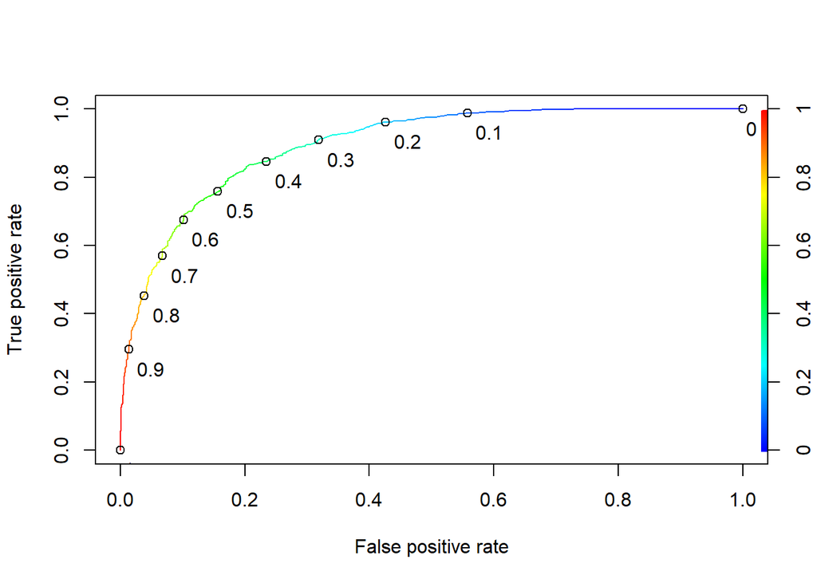

```r
model3_fitted <- predict(model3, type="response")
pred3.train.rocr <- prediction(model3_fitted, primaries_train$winner)
perf3.train.rocr <- performance(pred3.train.rocr, "tpr", "fpr")

plot(perf3.train.rocr, colorize=TRUE, print.cutoffs.at=seq(0,1,by=0.1), text.adj=c(-0.3,1.8))
```

We try to get a threshold which maximize the Y axis (True Positive Rate) and minimize the X axis (False Positive Rate). It seems like the best point would be 0.48. The table below is presenting the confusion matrix with threshold of 0.48:

```r
table(predictions = ifelse(model3_fitted > 0.48, "obama", "clinton"),
      actual = primaries_train$winner)
```

```
##            actual
## predictions clinton obama
##     clinton     913   188
##     obama       183   660
```

The rate of goodness of fit of the table above is the following:

```r
sum(diag(table(predictions = ifelse(model3_fitted > 0.48, "obama", "clinton"),
      actual = primaries_train$winner))/(sum(rowSums(table(predictions = ifelse(model3_fitted > 0.48, "obama", "clinton"),
      actual = primaries_train$winner)))))
```

```
## [1] 0.8091564
```

Another tool to help us assest how well our model fit the data it AUC, Area Under the Curve, of the ROC graph below. As long as the ROC graph is stratched to the top-left corner the better the fit, and simply the AUC is the area under it. When our model is base on pure random chance, the ROC graph will be straight line strached from the bottom left to the top right, and the area would be 0.5 (simply as the chance of flipping a coin). When we have the best model which predict perfectly the ROC will streached from the bottom left verticlly up all the way. In that option our AUC would be equal to 1. The AUC of our model, based on the train dataset is between 0.8 to 0.9 which considered to be “Excellent discrimination” acording to Hosmer & Lemeshow (2013). Applied logistic regression.

```r
as.numeric(performance(pred3.train.rocr, "auc")@y.values)
```

```
## [1] 0.8968182
```

Let’s make the prediction on the tests dataset to make sure that the model is indeed fitting well not only on the train dataset:

```r
model3_fitted_test<- predict(model3, type="response", newdata = primaries_test)
pred3.test.rocr <- prediction(model3_fitted_test, primaries_test$winner)
perf3.test.rocr <- performance(pred3.test.rocr, "tpr", "fpr")
as.numeric(performance(pred3.test.rocr, "auc")@y.values)
```

```
## [1] 0.8863087
```

It looks like both test and train dataset get good score on the AUC test.

### K Nearest Neighbor - KNN model

The second modeling would be *KNN*.  
The initial step in KNN modeling is to normalize the dataset. We do that in order to make sure that each of the variables will have the same impact in our modeling. The idea behind it, is the way the distance is calculated - KNN algorithm will use each variable is a dimention of space, and different variables a scaled differently, for example “number of vote” which range between a dozen of votes, to thousands, and on the other side, the variable “precent white” is range between 0 and 1 (as it represent the rate of white individules in the observed county). Therefore the euclidean distance in these two variables for the same observation would yield totally different distance.  
There are different way to normalize your data, we pick with normalizing it as standard normal distribusion where for each variable the mean equal to `0` with standard deviation of `1`:

```r
scaled_data <- primaries %>%
  keep(is.numeric)

scaled_data <- as.data.frame(scale(scaled_data,center = TRUE,scale = T))
scaled_data <- cbind(winner=primaries$winner, scaled_data)
```

We shall devide the scaled dataset into train and test:

```r
scaled_train <- scaled_data[training_index, ]
scaled_test <-  scaled_data[-training_index,]
```

The initial model consists of all the variables as predictors, with the default parameter `k`=5:

```r
model1_knn5 <-
  caret::train(winner ~ .,
        data = scaled_train,
        method = "knn")
```

Below is a table of the correct classifications:

```r
table(predictions = predict(model1_knn5,scaled_train), obsereved =  scaled_train$winner)
```

```
##            obsereved
## predictions clinton obama
##     clinton     972   164
##     obama       124   684
```

The ratio of goodness of fit for the training data is showing below:

```r
sum(diag(table(predict(model1_knn5,scaled_train), scaled_train$winner))/(sum(rowSums(table(predict(model1_knn5,scaled_train), scaled_train$winner)))))
```

```
## [1] 0.8518519
```

```r
set.seed(223322)
different_k <- data.frame(k = seq(1, 99, 4))

trainControl_cv_6_folds <- trainControl(method = "cv", number = 6,classProbs = T)

model2_knn_n <-
  train(winner ~ .,
        data = scaled_train,
        method = "knn",
        trControl = trainControl_cv_6_folds,
        tuneGrid = different_k,
        metric = "ROC")
```

In the plot below is showing the correct classification ratio for each K:

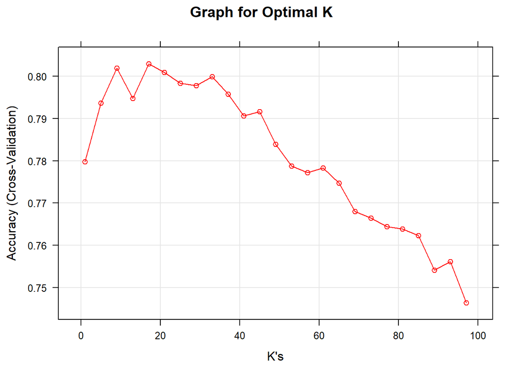

```r
plot(model2_knn_n,col = "red", main = "Graph for Optimal K", xlab= "K's")
```

From the graph above we can clearly see the `k`=17 will maximize our model accuracy.

```r
model2_knn_n$finalModel$k
```

```
## [1] 17
```

Below is a table of the correct classifications:

```r
table(predictions = predict(model2_knn_n,scaled_train), obsereved =  scaled_train$winner)
```

```
##            obsereved
## predictions clinton obama
##     clinton     968   183
##     obama       128   665
```

The correct ratio of goodness of fit is as follows:

```r
sum(diag(table(predict(model2_knn_n,scaled_train), scaled_train$winner))/(sum(rowSums(table(predict(model2_knn_n,scaled_train), scaled_train$winner)))))
```

```
## [1] 0.8400206
```

It seems like the initial KNN model yields better classifications than the current optimal K=17 model for the train dataset. Let’s see if there is indded difference in classification of prediction for the test dataset.

The table below presents the correct classifications for the initial model:

```r
table(predictions = predict(model1_knn5,scaled_test), obsereved =  scaled_test$winner)
```

```
##            obsereved
## predictions clinton obama
##     clinton     218    42
##     obama        55   170
```

Below we get to rate of correct classification for the initial model:

```r
sum(diag(table(predict(model1_knn5,scaled_test), scaled_test$winner))/(sum(rowSums(table(predict(model1_knn5,scaled_test), scaled_test$winner)))))
```

```
## [1] 0.8
```

The table below presents the correct classifications of the second model with k=17:

```r
table(predictions = predict(model2_knn_n,scaled_test), obsereved =  scaled_test$winner)
```

```
##            obsereved
## predictions clinton obama
##     clinton     228    43
##     obama        45   169
```

Below we get to rate of correct classification for the second model:

```r
sum(diag(table(predict(model2_knn_n,scaled_test), scaled_test$winner))/(sum(rowSums(table(predict(model2_knn_n,scaled_test), scaled_test$winner)))))
```

```
## [1] 0.8185567
```

Indeed it is clear to see that the optimized model with k=17 has better performance on the test dataset and that it should be the best model in this KNN section.

### SVM: Support Vector Machine

The last modeling is the SVM. First step in the SVM modeling is to have a look at different pairs of variables the the way their are distributed but more importantly is how the dependent variable, the `winner`, is spread in the distribution. The plots of the distributions is as follows:

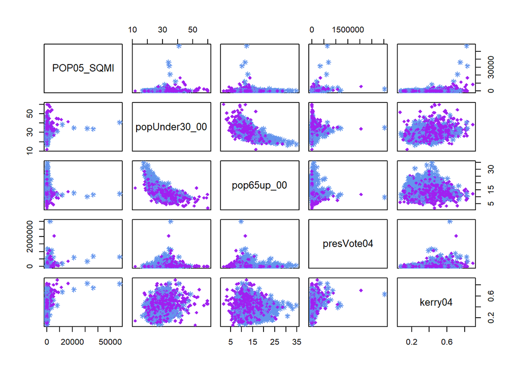

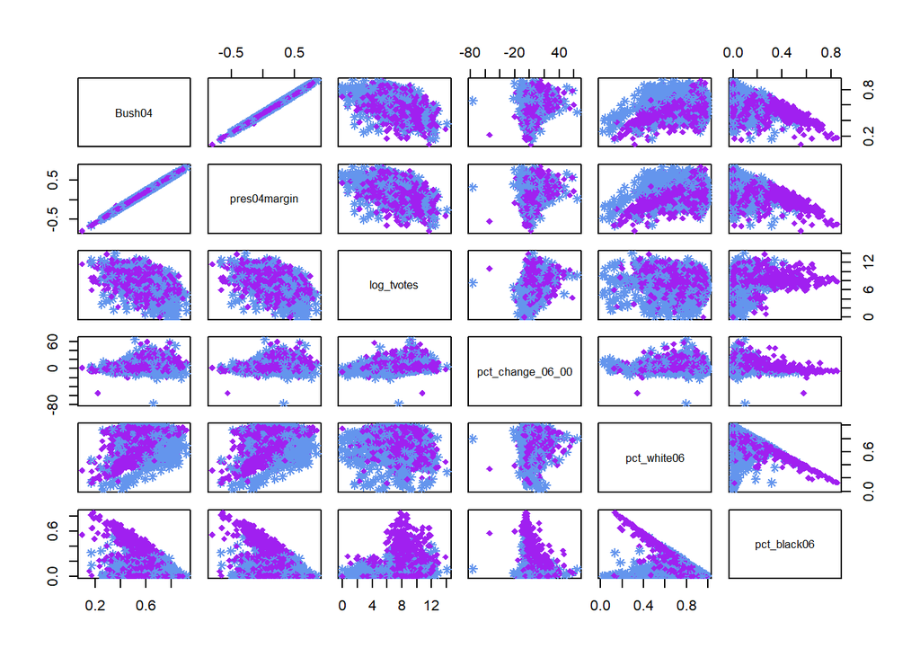

```r
pairs(primaries[,c(1:6)] %>% keep(is.numeric),
      col = c("cornflowerblue", "purple")[primaries$winner],   # Change color by group
      pch = c(8, 18)[primaries$winner])
```

As seen above it looks very clearly that a linear separation would not be suffficient to make good predictions. Moreover, it seems like for most variables, polynomial seperation would not be fit either.  
The best method would be Gaussian Radial Kernel seperation, as most of the distribution, one level of `winner` is “swallowed” and surrounded by the other.

The first model would be be a “basic” radial SVM model with all the variables as predictors, no cross validation, and all parameters are set to default:

```r
set.seed(123321)
model1.svm <- train(winner ~.,
                           data = primaries_train,
                           method = "svmRadial")
```

More details on the defaut model is below:

```r
model1.svm$finalModel
```

```
## Support Vector Machine object of class "ksvm"
##
## SV type: C-svc  (classification)
##  parameter : cost C = 1
##
## Gaussian Radial Basis kernel function.
##  Hyperparameter : sigma =  0.025352925106861
##
## Number of Support Vectors : 1054
##
## Objective Function Value : -787.14
## Training error : 0.119342
```

We can see that the `Cost` parameter was automatically set to be 1 and `sigma` to be 0.02535.  
Let’s take a look at the confusion matrix output below:

```r
confusionMatrix(
  predict(model1.svm, primaries_train),
   primaries_train$winner,
   positive = "obama"
)
```

```
## Confusion Matrix and Statistics
##
##           Reference
## Prediction clinton obama
##    clinton     992   142
##    obama       104   706
##
##                Accuracy : 0.8735
##                  95% CI : (0.8579, 0.8879)
##     No Information Rate : 0.5638
##     P-Value [Acc > NIR] : < 0.0000000000000002
##
##                   Kappa : 0.7414
##
##  Mcnemar's Test P-Value : 0.01832
##
##             Sensitivity : 0.8325
##             Specificity : 0.9051
##          Pos Pred Value : 0.8716
##          Neg Pred Value : 0.8748
##              Prevalence : 0.4362
##          Detection Rate : 0.3632
##    Detection Prevalence : 0.4167
##       Balanced Accuracy : 0.8688
##
##        'Positive' Class : obama
##
```

Even a simple basic Radial SVM model we preform nice accuracy rate of 0.8735 in classifying the `winner`. We will try to improve that basic model with cross validation. We start with taking different Cost level (`C`) and `sigma`’s as follows:

```r
df_cSigma <-
  expand.grid(C = c(0.01, 0.05, 0.1, 0.5, 1,3, 5),
              sigma = c(seq(0.01,0.05,0.01), 0.08, 0.1, 0.2, 0.5, 1))

headtail(df_cSigma)
```

```
##        C sigma
## 1   0.01  0.01
## 2   0.05  0.01
## 3    0.1  0.01
## 4    0.5  0.01
## ...  ...   ...
## 67   0.5     1
## 68     1     1
## 69     3     1
## 70     5     1
```

We use repeated cross validation with 5 folds which repeated 3 times (15 times in total) in order to get the best model with best `C` and `sigma` (from the data frame above) which will maximize our model results.

```r
myTrainCont <- trainControl(method = "repeatedcv",
                           number = 5,
                           repeats = 3)
```

```r
model2.svm <- train(winner ~.,
                           data = primaries_train,
                           tuneGrid = df_cSigma,    #two cells above
                           trControl = myTrainCont, #one cell above
                           method = "svmRadial")
```

Below are the details for the best model which was optimized by the cross validation process:

```r
model2.svm$finalModel
```

```
## Support Vector Machine object of class "ksvm"
##
## SV type: C-svc  (classification)
##  parameter : cost C = 3
##
## Gaussian Radial Basis kernel function.
##  Hyperparameter : sigma =  0.03
##
## Number of Support Vectors : 953
##
## Objective Function Value : -1731.697
## Training error : 0.077675
```

The optimal cost and sigma are 3 and 0.03 respectivly.

Below is the confusion matrix for the current model perdictions:

```r
confusionMatrix(
  predict(model2.svm, primaries_train),
   primaries_train$winner,
   positive = "obama"
)
```

```
## Confusion Matrix and Statistics
##
##           Reference
## Prediction clinton obama
##    clinton    1019    90
##    obama        77   758
##
##                Accuracy : 0.9141
##                  95% CI : (0.9007, 0.9262)
##     No Information Rate : 0.5638
##     P-Value [Acc > NIR] : <0.0000000000000002
##
##                   Kappa : 0.825
##
##  Mcnemar's Test P-Value : 0.3531
##
##             Sensitivity : 0.8939
##             Specificity : 0.9297
##          Pos Pred Value : 0.9078
##          Neg Pred Value : 0.9188
##              Prevalence : 0.4362
##          Detection Rate : 0.3899
##    Detection Prevalence : 0.4295
##       Balanced Accuracy : 0.9118
##
##        'Positive' Class : obama
##
```

We get quite surprising results as the accuracy of the optimized SVM model is : 0.9141!  
Let’s check if the model preforms as good on the test dataset as it did on the train dataset:

```r
confusionMatrix(
  predict(model2.svm, primaries_test),
   primaries_test$winner,
   positive = "obama"
)
```

```
## Confusion Matrix and Statistics
##
##           Reference
## Prediction clinton obama
##    clinton     230    20
##    obama        43   192
##
##                Accuracy : 0.8701
##                  95% CI : (0.8369, 0.8987)
##     No Information Rate : 0.5629
##     P-Value [Acc > NIR] : < 0.00000000000000022
##
##                   Kappa : 0.7392
##
##  Mcnemar's Test P-Value : 0.005576
##
##             Sensitivity : 0.9057
##             Specificity : 0.8425
##          Pos Pred Value : 0.8170
##          Neg Pred Value : 0.9200
##              Prevalence : 0.4371
##          Detection Rate : 0.3959
##    Detection Prevalence : 0.4845
##       Balanced Accuracy : 0.8741
##
##        'Positive' Class : obama
##
```

We can see that model still preforms well on the test dataset. On one hand, the model doesn’t predict as good as it did on the train dataset, but on the other hand it looks like it performs better on tests dataset than the other models! We shall check that on the next section of model comparison.

### Models Comparison and Conclusion

Akaike Information Criterion (*AIC*) is a criterion score which rewards for goodness of fit and panelize for complexity. We use AIC to compare models to determine which one is the best from all the alternatives. There are 2 conditions before we can compare models with AIC: the dependent variable should be the same for all models, as well as the dataset. The former condition is met in all 3 models, however the dataset is different in KNN, as the dataset was normalized.  
Let us compare the goodness of fit for all selected models, `model3` of logit, `model2_knn_n` off KNN and `model2.svm` of SVM, for the test dataset:

For the logit best model, `model3`, the accuracy is 80.4% correct classifications:

```r
confusionMatrix(
factor(ifelse(predict(model3, newdata = primaries_test, type = "response")>=0.47,"obama","clinton") ),
factor(primaries_test$winner),
positive = "obama"
)
```

```
## Confusion Matrix and Statistics
##
##           Reference
## Prediction clinton obama
##    clinton     218    40
##    obama        55   172
##
##                Accuracy : 0.8041
##                  95% CI : (0.766, 0.8385)
##     No Information Rate : 0.5629
##     P-Value [Acc > NIR] : <0.0000000000000002
##
##                   Kappa : 0.6051
##
##  Mcnemar's Test P-Value : 0.1509
##
##             Sensitivity : 0.8113
##             Specificity : 0.7985
##          Pos Pred Value : 0.7577
##          Neg Pred Value : 0.8450
##              Prevalence : 0.4371
##          Detection Rate : 0.3546
##    Detection Prevalence : 0.4680
##       Balanced Accuracy : 0.8049
##
##        'Positive' Class : obama
##
```

```r
confusionMatrix(
predict(model2_knn_n, newdata = scaled_test),
primaries_test$winner)
```

```
## Confusion Matrix and Statistics
##
##           Reference
## Prediction clinton obama
##    clinton     228    43
##    obama        45   169
##
##                Accuracy : 0.8186
##                  95% CI : (0.7813, 0.8519)
##     No Information Rate : 0.5629
##     P-Value [Acc > NIR] : <0.0000000000000002
##
##                   Kappa : 0.6317
##
##  Mcnemar's Test P-Value : 0.9151
##
##             Sensitivity : 0.8352
##             Specificity : 0.7972
##          Pos Pred Value : 0.8413
##          Neg Pred Value : 0.7897
##              Prevalence : 0.5629
##          Detection Rate : 0.4701
##    Detection Prevalence : 0.5588
##       Balanced Accuracy : 0.8162
##
##        'Positive' Class : clinton
##
```

```r
confusionMatrix(
  predict(model2.svm, primaries_test),
   primaries_test$winner,
   positive = "obama"
)
```

```
## Confusion Matrix and Statistics
##
##           Reference
## Prediction clinton obama
##    clinton     230    20
##    obama        43   192
##
##                Accuracy : 0.8701
##                  95% CI : (0.8369, 0.8987)
##     No Information Rate : 0.5629
##     P-Value [Acc > NIR] : < 0.00000000000000022
##
##                   Kappa : 0.7392
##
##  Mcnemar's Test P-Value : 0.005576
##
##             Sensitivity : 0.9057
##             Specificity : 0.8425
##          Pos Pred Value : 0.8170
##          Neg Pred Value : 0.9200
##              Prevalence : 0.4371
##          Detection Rate : 0.3959
##    Detection Prevalence : 0.4845
##       Balanced Accuracy : 0.8741
##
##        'Positive' Class : obama
##
```

From the outputs above it’s obvious that SVM performs the best on both train and test datasets in all parameters: Balanced Accuracy, Sensitivity and Specificity. However there is a downside to it, it dements lots of processing resourses and time. The former models were preforming well relatively to the time and computational resources.  
For big datasets SVM is mostly not suited if the resources are limited and one might as well switch to other methods such as Logistic, Probit, KNN and other classification algorithms.  
For our case SVM seems to be the best option!

**Thank you for reading!**